# Regresión: Modelos Estadísticos

Conjunto de Datos: Cheddar Faraway

Daniel López Montero

Rodrigo de la Nuez Moraleda

Jose

David

25/03/2022

Abstract

Hemos analizado con las herramientas proporcionadas en el curso de Modelos Estadísticos el conjunto de datos, *Cheddar*, distribuido en la librería Faraway de R. Para ello hemos utilizado diversas técnicas de regresión lineal y no lineal.

# Introducción

En un estudio de queso Cheddar realizado en el Valle de Latrobe (Victoria, Australia), se estudiaron muestras de queso en las que se analizó su composición química y fueron dadas a probar a distintos sujetos para que valoraran su sabor. Los valores asignados a cada queso son el resultado de combinar las distintas valoraciones.

El DataFrame **cheddar** de la librería **faraway** consiste de 30 muestras de queso Cheddar en las que se ha medido el sabor (*taste*) y las concentraciones de ácido acético (*Acetic*), ácido sulfhídrico (*H2S*) y lactosa (*Lactic*).

Tenenemos un conjunto de datos en el que se recogen observaciones de una cata de quesos, nuestras variables son:

**· Taste:** una valoración subjetiva de los jueces.

**· Acetic:** la concentración de ácido acético en un queso de terminado en esca la logarítmica

**· H2S:** la concentración de sulfito de hidrógeno en escala logarítmica.

**· Lactic:** Concentración de ácido láctico

A lo largo del documento hacemos uso de las siguientes librerias de R:

```r
library(faraway)
library(leaps)
library(MASS)
library(PASWR)
library(car)
library(ggplot2)
library(plyr)
library(GGally)
library(corrplot)
library(plotly)
library(scatterplot3d)
library(cowplot)
```

Vamos a utilizar el dataset *Cheddar*. Cargamos los datos y enseñamos las primeras observaciones.

```r
# load cheddar cheddar
data(cheddar)
head(cheddar)
```

|  | taste | Acetic | H2S | Lactic |
| --- | --- | --- | --- | --- |
| 1 | 12.3 | 4.543 | 3.135 | 0.86 |
| 2 | 20.9 | 5.159 | 5.043 | 1.53 |
| 3 | 39.0 | 5.366 | 5.438 | 1.57 |
| 4 | 47.9 | 5.759 | 7.496 | 1.81 |
| 5 | 5.6 | 4.663 | 3.807 | 0.99 |
| 6 | 25.9 | 5.697 | 7.601 | 1.09 |

Si en nuestro dataset tuviesemos entradas vacías (NA), tenemos varias posibilidades para lidiar con este problema:

- No utilizar/Eliminar las observación que contienen valores.
- No utilizar/Eliminar las variables que contienen las entradas vacías.
- Intentar completar los valores. Existen métodos menos y más sofisitcados:
  - Remplezar con la **media, media o moda**.
  - Crear una **nueva categoría** para valores vacíos.
  - Utilizar algún modelo de **regresión**.
  - Usar un modelo de **K-Nearest Neighbors (KNN)**.

```r
# check if any entry has a missing value (NA)
any(is.na(cheddar))
```

```
[1] FALSE
```

```r
sapply(cheddar, class)
```

```
    taste    Acetic       H2S    Lactic
"numeric" "numeric" "numeric" "numeric"
```

Toas las variables son numéricas (**cuantitativas**). No hay que transformar las variables no cuantitativas (**cualitativas**), conviertiendolas en variables binarias. Para ello, podríamos deberíamos hacer encoding a variables binarias, el lenguage de programación R nos permite utilizar *as.numeric*.

Con estas variables vamos a intentar **explicar** cómo los valores observados de una variable Y (taste) dependen de los valores de otras variables (Acetic, H2S, Latcic), a través de una relación funcional del tipo Y = f(X) También vamos a intentar **predecir** el valor de la variable Y para valores no observados de las variables X.

Usamos el número de observaciones para determinar los conjuntos de train y test.

```r
numObs <- dim(cheddar)[1]
numObs
```

```
[1] 30
```

Tenemos 30 observaciones en nuestro dataset. Ahora procedemos a divirlo en el *conjunto de train y test*. El primero lo utilizaremos para entrenar nuestros modelos y el segundo lo usamos para cuantificar el error de los modelos.

Ahora nos hacemos las siguientes preguntas: ¿Podemos suponer que la distribución de las variables es normal?,¿Tenemos alguna en la que falten datos?, ¿Tenemos *outliers*?, etc. En las siguientes secciones trataremos de responder a estas preguntas y muchas otras acercar de nuestro conjunto de datos.

```r
# Para asegurar que sea reproducible utilizamos una semilla, que permite fijar los valores pseudoaleatorios obtenidos en muchas de las funciones utilizadas.
set.seed(1)
train <- sample(c(TRUE, FALSE),
                size = nrow(cheddar),
                replace = TRUE,
                prob = c(0.7, 0.3))
test <- !train
```

Hacemos un pequeño estudio preliminar de nuestras variables. Mostramos un scatter plot de las cada variable contrastada con el resto. Esto permite ver *a ojo* si algún par de variables tiene correlación.

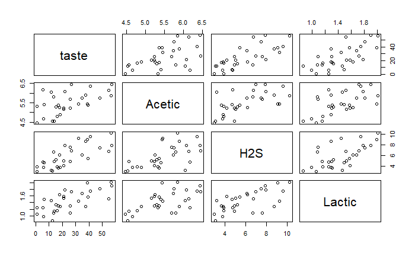

```r
plot(cheddar)
```

Ahora, utilizamos la funcón *summary* de R, la cual nos permite estimar algunos de las características de la distribución del dataset. La siguiente tabla nos muestra los estadísticos más comunes: el mínimo, máximo, mediana, media y el 1er y 3er cuartil.

```r
summary(cheddar) # Distribución de las variables
```

```
     taste           Acetic           H2S             Lactic
 Min.   : 0.70   Min.   :4.477   Min.   : 2.996   Min.   :0.860
 1st Qu.:13.55   1st Qu.:5.237   1st Qu.: 3.978   1st Qu.:1.250
 Median :20.95   Median :5.425   Median : 5.329   Median :1.450
 Mean   :24.53   Mean   :5.498   Mean   : 5.942   Mean   :1.442
 3rd Qu.:36.70   3rd Qu.:5.883   3rd Qu.: 7.575   3rd Qu.:1.667
 Max.   :57.20   Max.   :6.458   Max.   :10.199   Max.   :2.010
```

Ploteamos las gráficas de dispersion entre la variable respuesta *taste* y las variables predictoras *Acetic, H2S, Lactic*.

```r
layout(matrix(1:3, nrow = 1))

# plot taste ~ Acetic
plot(Acetic, taste,
     main = "Relación entre Taste y Acetic",
     xlab = "Acetic", ylab = "Taste",
     pch = 20, frame = FALSE)

# plot taste ~ H2S
plot(H2S, taste,
     main = "Relación entre Taste y H2S",
     xlab = "H2S", ylab = "Taste",
     pch = 20, frame = FALSE)
```

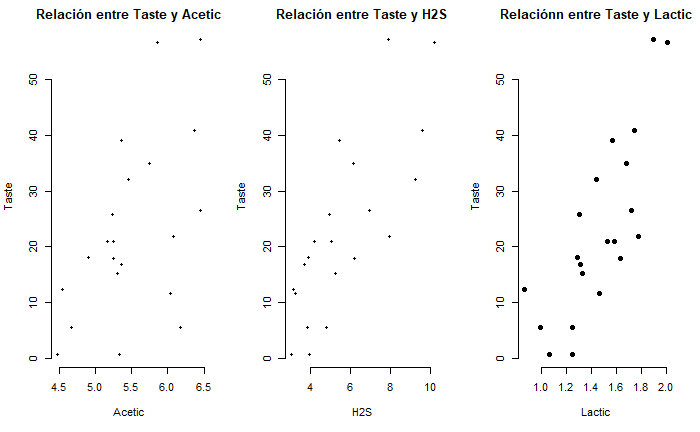

```r
# plot taste ~ Lactic
plot(Lactic, taste,
     main = "Relaciónn entre Taste y Lactic",
     xlab = "Lactic", ylab = "Taste",
     pch = 19, frame = FALSE)
```

Podemos observar que la que aperentemente guarda una menor relación lineal con taste es la variable Acetic, esto será comprobado con distintos tests.

# Estudio y evaluación del modelo completo.

Simplificamos nuestra notación para las variables. Intentaremos predecir la variable *taste* usando el resto de variables. Para empezar, definimos el modelo completo, el cual se usan todas las variables para nuestro modelo lineal múltiple.

$$Y_i =\beta_0 + \beta_1 x_{i1} + \dots + \beta_{p-1}x_{i(p-1)} + \epsilon_i,\quad i=1,\dots,n$$
donde $Y_i$ es el valor de la variable respuesta para el individuo $i$-ésimo,
$\beta_0$ y los $\beta_j$ son los par´ametros $j = 1, ..., p - 1$,
$x_{ij}$ son los elementos de la matriz de las variables explicativas
$\epsilon_i$ es el término del error aleatorio que suponemos que se distribuye como una $\mathcal{N}(0,\sigma^2)$, donde $\sigma^2$ es la varianza que suele ser desconocida.

## Resolución mediante matrices

Utilizamos el método de mínimos cuadrados que estima los valores $\hat{\beta}$ intentando minimizar los errores $\epsilon$. Como hemos visto en clase, la fórmula que se deduce es:

$$\hat{\beta} = (X^tX)^{-1}X^tY$$
donde $X$ es una columna de 1’s concatenada con las variables que usamos para predecir. Es importante clarificar que en este proceso solo usamos el training set.

```r
x <- model.matrix( ~ Acetic + H2S + Lactic, data = cheddar[train,])
betahat <- solve(crossprod(x, x), crossprod(x, taste))
betahat <- c(betahat)
betahat
```

```
[1] -14.016212  -5.066965   3.217036  31.938449
```

Por tanto, aproximamos las $\beta$ modelo lineal completo con los valores de $\hat{\beta}_0,\dots,\hat{\beta}_3$ con los siguientes valores:

$$\hat{\beta}_0=-14.016212,\quad\hat{\beta}_1=-5.066965,\quad\hat{\beta}_2=3.217036,\quad\hat{\beta}_3=31.938449$$

## Resolución usando librerias de R

Podemos utilizar la función $lm$, ya programada en R.

```r
model.all.lm <- lm(taste ~ ., data = cheddar[train,])
model.all.lm$coefficients # Coeficientes del modelo completo
```

```
(Intercept)      Acetic         H2S      Lactic
 -14.016212   -5.066965    3.217036   31.938449
```

Evidentemente los resultados son los mismos.

Estudiemos preliminarmente si es un modelo lineal adecuado, para ello comprobaremos las hipótesis estándar del modelo lineal de regresión usando el **test de normalidad Shapiro-Wilk**. La función $shapiro.test$ le pasamos por parámetro el residuo/error de cada una de las muestras y nos devuelve un $p$-valor.

```r
shapiro.test(resid(model.all.lm))
```

```
    Shapiro-Wilk normality test

data:  resid(model.all.lm)
W = 0.97755, p-value = 0.8865
```

Observamos que estamos en la hipótesis de que el error nuestro modelo se distribuye de manera normal, ya que el p-valor es $0.8865 > 0.05$.

Ahora nos preguntamos si hay variables que tienen un mayor impacto en el modelo. Estas variables podrían ser *outliers* y podríamos deshecharlas del training set ya que podrían estar perjudicando la predicción del modelo negativamente.

```r
summary(model.all.lm)
```

```
Call:
lm(formula = taste ~ ., data = cheddar[train, ])

Residuals:
     Min       1Q   Median       3Q      Max
-15.7641  -4.0925  -0.7499   4.3790  17.7545

Coefficients:
            Estimate Std. Error t value Pr(>|t|)
(Intercept)  -14.016     20.490  -0.684   0.5032
Acetic        -5.067      5.120  -0.990   0.3363
H2S            3.217      1.472   2.185   0.0432 *
Lactic        31.938     12.852   2.485   0.0237 *
---
Signif. codes:  0 ‘***’ 0.001 ‘**’ 0.01 ‘*’ 0.05 ‘.’ 0.1 ‘ ’ 1

Residual standard error: 9.109 on 17 degrees of freedom
Multiple R-squared:  0.7251,    Adjusted R-squared:  0.6765
F-statistic: 14.94 on 3 and 17 DF,  p-value: 5.103e-05
```

Una vez hemos concluido que aunque estamos en las hipótesis de regresión lineal el modelo completo a pesar de ser el más complejo probablemente da resultados similares a otro más simple.

#### Correlaciones y tabla de resultados con el estudio de sus p-valores

Usamos el paquete $GGplot$ de R, el cual nos permite visualizar la correlación y dispersión entre las distintas variables.

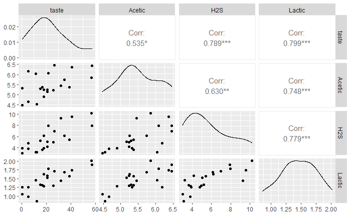

```r
corplot <- ggpairs(cheddar[train,], progress=FALSE)
corplot
```

Para medir la correlación podemos utilizar también la función *cor*, que utiliza el método de **Pearon**. Podemos observar que la correlación de la propia variable con sigo misma es máxima (=1).

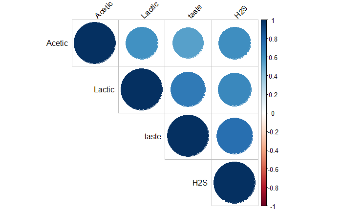

```r
mat_cor <- cor(cheddar, method = "pearson")
corrplot(mat_cor, type = "upper", order = "hclust", tl.col = "black", tl.srt = 45)
```

Ahora utilizamos el anális **anova** (Analysis of Variance), para justificar si podemos eliminar alguna variable del modelo.

```r
anova(model.all.lm)
```

```
Analysis of Variance Table

Response: taste
          Df Sum Sq Mean Sq F value    Pr(>F)
Acetic     1 1466.8 1466.80 17.6761 0.0005961 ***
H2S        1 1740.8 1740.83 20.9783 0.0002660 ***
Lactic     1  512.5  512.50  6.1761 0.0236545 *
Residuals 17 1410.7   82.98
---
Signif. codes:  0 ‘***’ 0.001 ‘**’ 0.01 ‘*’ 0.05 ‘.’ 0.1 ‘ ’ 1
```

Todos nuestros p-valores son adecuados a un nivel $\alpha$ = 0.05. En nuestro caso nos vale, sin embargo, la variable *Lactic* no lo cumpliría si disminuimos el nivel de $\alpha$ a una cota inferior como 0.01.

## ¿Tiene *outliers* nuestra muestra?

Para comprobarlo basta realizar el **test de Bonferroni** sobre nuestro modelo completo:

```r
outlierTest(model.all.lm)
```

```
No Studentized residuals with Bonferroni p < 0.05
Largest |rstudent|:
```

|  | rstudent | unadjusted p-value | Bonferroni p |
| --- | --- | --- | --- |
| 12 | 2.458893 | 0.025711 | 0.53993 |

Concluimos con un nivel $\alpha$ = 0.05 que no tenemos ningún outlier en nuestra. Lo más cercano a un *outlier* que tenemos es la observación número 12, que tiene un valor **Bonferroni p** de 0.53993 (no se acerca a 0.05). Por tanto, no tenemos razones por las que eliminar alguna observación inusual de nuestro conjunto de datos.

Esto se puede comprobar graficamente a través del siguiente gráfico, el cual mide la influencia de cada observación sobre cada una de las betas de nuestro modelo. Vemos que la que más influye es la antes mencionada obsercación 12.

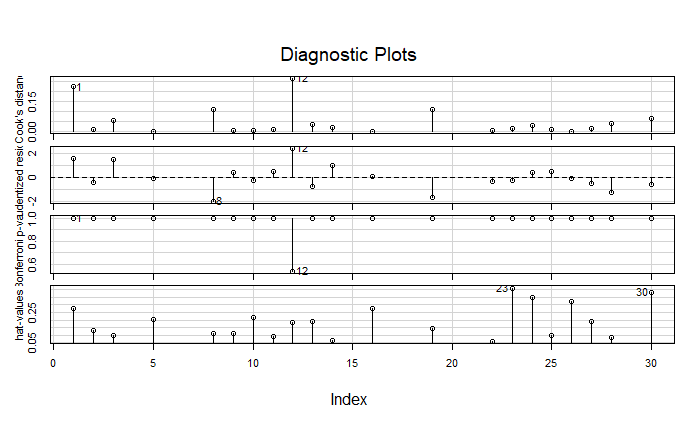

```r
influenceIndexPlot(model.all.lm)
```

Podemos ver que hay un pequeño grupo de observaciones que aunque no sean *outliers* pueden alterar la claridad del modelo.

## ¿Cuál es el mejor modelo?

Como dice el **Principio de la Navaja de Ockham**, a menudo la explicación más simple es la correcta. Queremos seleccionar predictores que explican los datos de la manera más simple posible, sin disminuir la calidad de las predicciones mucho.

### Método Backward

Partimos del modelo completo estudiado en la sección anterior y aplicamos con $\alpha$ = 0.05, el metodo de Backward, que consiste en eliminar la variable que *menos influya* a la predicción.

```r
drop1(model.all.lm, test = "F")
```

```
Single term deletions

Model:
taste ~ Acetic + H2S + Lactic
       Df Sum of Sq    RSS     AIC F value  Pr(>F)
<none>              1410.7  96.354
Acetic  1     81.26 1492.0  95.530  0.9792 0.33627
H2S     1    396.17 1806.9  99.551  4.7741 0.04318 *
Lactic  1    512.50 1923.2 100.862  6.1761 0.02365 *
---
Signif. codes:  0 ‘***’ 0.001 ‘**’ 0.01 ‘*’ 0.05 ‘.’ 0.1 ‘ ’ 1
```

Quitamos Acetic del modelo debido que su p-valor es > 0.05

```r
model.backward <- update(model.all.lm, . ~ . - Acetic)
drop1(model.backward, test = "F")
```

```
Single term deletions

Model:
taste ~ H2S + Lactic
       Df Sum of Sq    RSS    AIC F value  Pr(>F)
<none>              1492.0 95.530
H2S     1    361.58 1853.5 98.087  4.3624 0.05122 .
Lactic  1    443.44 1935.4 98.994  5.3499 0.03275 *
---
Signif. codes:  0 ‘***’ 0.001 ‘**’ 0.01 ‘*’ 0.05 ‘.’ 0.1 ‘ ’ 1
```

Repetimos el proceso con la variable H2S, ya que tiene un valor mayor que $\alpha = 0.05$

```r
model.backward <- update(model.backward, . ~ . - H2S)
drop1(model.backward, test = "F")
```

```
Single term deletions

Model:
taste ~ Lactic
       Df Sum of Sq    RSS     AIC F value    Pr(>F)
<none>              1853.5  98.087
Lactic  1    3277.3 5130.8 117.469  33.594 1.388e-05 ***
---
Signif. codes:  0 ‘***’ 0.001 ‘**’ 0.01 ‘*’ 0.05 ‘.’ 0.1 ‘ ’ 1
```

El p-valor es menor que $\alpha = 0.05$. Por tanto, hemos concluido, ya que no tenemos suficiente certeza para poder eliminar otra variable.

Por tanto, tenemos como resultado que la variable que mejor explica el *taste* es *Lactic*.

```r
# Modelo resultante del método Backward
model.backward
```

```
Call:
lm(formula = taste ~ Lactic, data = cheddar[train, ])

Coefficients:
(Intercept)       Lactic
     -39.82        42.95
```

Modelo resultante: **taste ~ Lactic.**

### Método Forward

El método Forward consiste en empezar con un modelo de una variable y vamos añadiendo las que más influyan. De esta manera tenemos:

```r
SCOPE<-(~.+Acetic + H2S + Lactic)
model.forward.lm <- lm(taste~1,data= cheddar[train,])
add1(model.forward.lm,scope=SCOPE,test="F")
```

```
Single term additions

Model:
taste ~ 1
       Df Sum of Sq    RSS     AIC F value    Pr(>F)
<none>              5130.8 117.469
Acetic  1    1466.8 3664.0 112.398  7.6062   0.01252 *
H2S     1    3195.4 1935.4  98.994 31.3700 2.115e-05 ***
Lactic  1    3277.3 1853.5  98.087 33.5944 1.388e-05 ***
---
Signif. codes:  0 ‘***’ 0.001 ‘**’ 0.01 ‘*’ 0.05 ‘.’ 0.1 ‘ ’ 1
```

Actualizamos añadiendo Lactic por tener el menor p-valor.

```r
model.forward.lm <- update(model.forward.lm, .~. + Lactic)
add1(model.forward.lm,scope=SCOPE,test="F")
```

```
Single term additions

Model:
taste ~ Lactic
       Df Sum of Sq    RSS    AIC F value  Pr(>F)
<none>              1853.5 98.087
Acetic  1     46.68 1806.9 99.551  0.4650 0.50399
H2S     1    361.58 1492.0 95.530  4.3624 0.05122 .
---
Signif. codes:  0 ‘***’ 0.001 ‘**’ 0.01 ‘*’ 0.05 ‘.’ 0.1 ‘ ’ 1
```

Con nivel de significación $\alpha$ = 0.05 este sería nuestro modelo final.

```r
model.forward.lm
```

```
Call:
lm(formula = taste ~ Lactic, data = cheddar[train, ])

Coefficients:
(Intercept)       Lactic
     -39.82        42.95
```

Modelo resultante: **taste ~ Lactic.**

### Observación

A este modelo, **taste ~ Lactic** le vamos a dar un nombre, posteriormente estudiaremos los problemas que presenta.

```r
model.final1 <- lm(taste ~ Lactic, data = cheddar[train,])
```

## Construcción por criterios

En esta subsección trataremos de encontrar un candidato a mejor modelo, construyendo nuestros modelos usando distintos enfoques.

### $R^2$ ajustado

Es un criterio de optimización que se utiliza en la construcción de modelos, se basa en el estadísitico $R^2$.

```r
models <- regsubsets(taste ~ ., data = cheddar[train,])
summary(models)
```

```
Subset selection object
Call: regsubsets.formula(taste ~ ., data = cheddar[train, ])
3 Variables  (and intercept)
       Forced in Forced out
Acetic     FALSE      FALSE
H2S        FALSE      FALSE
Lactic     FALSE      FALSE
1 subsets of each size up to 3
Selection Algorithm: exhaustive
         Acetic H2S Lactic
1  ( 1 ) " "    " " "*"
2  ( 1 ) " "    "*" "*"
3  ( 1 ) "*"    "*" "*"
```

```r
MR2adj <- summary(models)$adjr2
MR2adj
```

```
[1] 0.6197312 0.6769081 0.6765346
```

```r
which.max(MR2adj)
```

```
[1] 2
```

```r
summary(models)$which[which.max(MR2adj), ]
```

```
(Intercept)      Acetic         H2S      Lactic
       TRUE       FALSE        TRUE        TRUE
```

Modelo resultante: **taste ~ H2S + Lactic.**

### Criterio de $C_p$ de Mallow

Este criterio se basa en el estadístico de Mallow $C_p$.

```r
MCp <- summary(models)$cp
MCp
```

```
[1] 5.336570 2.979216 4.000000
```

```r
which.min(MCp)
```

```
[1] 2
```

```r
summary(models)$which[which.min(MCp), ]
```

```
(Intercept)      Acetic         H2S      Lactic
       TRUE       FALSE        TRUE        TRUE
```

Modelo resultante: **taste ~ H2S + Lactic.**

### Criterio de Informacion de Bayes (BIC)

```r
MBIC <- summary(models)$bic
MBIC
```

```
[1] -15.29253 -16.80519 -14.93673
```

```r
which.min(MBIC)
```

```
[1] 2
```

```r
summary(models)$which[which.min(MBIC), ]
```

```
(Intercept)      Acetic         H2S      Lactic
       TRUE       FALSE        TRUE        TRUE
```

Modelo resultante: **taste ~ H2S + Lactic.**

### Criterio de Informacion de Akaike (AIC)

```r
stepAIC(model.all.lm, scope = SCOPE, k = 2)
```

```
Start:  AIC=96.35
taste ~ Acetic + H2S + Lactic

         Df Sum of Sq    RSS     AIC
- Acetic  1     81.26 1492.0  95.530
<none>                1410.7  96.354
- H2S     1    396.17 1806.9  99.551
- Lactic  1    512.50 1923.2 100.862

Step:  AIC=95.53
taste ~ H2S + Lactic

         Df Sum of Sq    RSS    AIC
<none>                1492.0 95.530
+ Acetic  1     81.26 1410.7 96.354
- H2S     1    361.58 1853.5 98.087
- Lactic  1    443.44 1935.4 98.994

Call:
lm(formula = taste ~ H2S + Lactic, data = cheddar[train, ])

Coefficients:
(Intercept)          H2S       Lactic
    -31.122        3.054       25.210
```

Modelo resultante: **taste ~ H2S + Lactic.**

Nótese que los modelos obtenidos por metodos de criterios coinciden.

```r
model.crit <- lm(taste ~ H2S + Lactic, data=cheddar[train,])
anova(model.crit, model.all.lm)
```

[output not shown]

A este , **taste ~ H2S + Lactic** le vamos a dar un nombre, en la siguiente sección lo estudiaremos con detalle.

```r
model.final2 <- lm(taste ~ H2S + Lactic, data = cheddar[train,])
```

# Diagnóstico

En esta sección estudiaremos si nuestros *modelos* cumplen las condiciones necesarias de un modelo de regresión lineal.

Nuestro enfoque consistirá en un analisis gráfico, acompañado de tests estadísticos en los casos en los que se aprecie una discrepancia notable.

## ¿Son nuestros *modelos*, modelos de regresión lineal?: Comprobación de hipótesis.

En la sección 3 se toma un enfoque *naïve* a la hora de construir los modelos, ya que no hemos estudiado si hay observaciones influyentes, podríamos tener una muestra que no es la adecuada para el estudio de nuestros datos.

Un modelo de regresión lineal debe satisfacer las siguientes hipótesis con nivel de siginificación $\alpha$ adecuado:

1. Los errores $\epsilon_{i}$ tienen distribución normal.
2. Los errores $\epsilon_{i}$ tienen media cero.
3. Los errores $\epsilon_{i}$ tienen varianza constante.
4. Los errores $\epsilon_{i}$ no están correlacionados.

### Model.final1

```r
plot(model.final1)
residuos <- resid(model.final1)
```

[output not shown]

### Model.final2

```r
plot(model.final2)
residuos2 <- resid(model.final2)
```

[output not shown]

### Comprobación de hipótesis

A fin de exponer con una mayor claridad los resultados y ahorrar espacio, recogemos los resultados de los tests en una tabla en la que observamos si se verifican las hipotesis del modelo de regrsión lineal.

```r
library(knitr)
```

```r
res.aov <- aov(model.final1)
res.aov2 <- aov(model.final2)
shap1 <- shapiro.test(residuos)$p.value
shap2 <- shapiro.test(residuos2)$p.value

t1 <- t.test(residuos, mu = 0, alternative = "two.sided")$p.value
t2 <- t.test(residuos2, mu = 0, alternative = "two.sided")$p.value

aov1L <- summary(res.aov)[[1]][["Pr(>F)"]][1]
aov2L <- summary(res.aov2)[[1]][["Pr(>F)"]][1]
aov2H <-  summary(res.aov2)[[1]][["Pr(>F)"]][2]

dw1 <- durbinWatsonTest(model.final1)[[3]]#CORREGIR PROBLEMILLA; NO SON ESTOS LOS P
dw2 <- durbinWatsonTest(model.final2)[[3]]


df_hip <- data.frame("Distribución_normal" = c(shap1,shap2, 0.05,"Shapiro-Wilk"),
                     "Media_0" = c(t1,t2, 0.05,"t-Test"),
                     "Varianza_no_constante_H2S" = c("No participa en modelo",aov2H,0.05,"ANOVA"),
                     "Varianza_no_constante_L" = c(aov1L,aov2L,0.05,"ANOVA"),
                     "No_Autocorrelación" = c(dw1,dw2,0.05, "Durvin-Watson"))
rownames(df_hip) <- c("model.final1","model.final2","p-valor","Test usado")
```

```r
df_hip
```

[output not shown]